# Lab 2: Transfer Learning & Transformers: Comparison of Transformer Architecture to Other Neural Networks in Evaluation of Movie Reviews and Ratings

Group Members:

- Parker Brown
- Suma Chackola
- Chris Peters
- Oliver Raney

**The execution of this lab was performed collaboratively across 4 computers. Therefore, while the individual cells are not all shown with the direct execution results, the code presented in those cells was utilized to produce the results in this notebook.**

## Contents

- 1.0 Introduction & Dataset Overview
- 2.0 Transfer Learning Foundational Model
- 3.0 Splitting the Data
- 4.0 Training a Model from Scratch
- 5.0 Training a Model by Transfer Learning from Foundational Model
- 6.0 Fine-Tuning the Model
- 7.0 Results: Comparing All Investigated Models

Back to Top

## 1.0 Introduction & Dataset Overview

#### Give an overview of the dataset you have chosen to use. What is the classification task. Is this multi-task? Explain. What is the feature data? Who collected the data? Why? When? Is the data multi-modal? What evaluation criteria will you be using and why?

In this lab, we are performing classification on Movie Review text to associate the text of the review with an overall "positivity" rating of Positive, Neutral, or Negative. By reviewing the text as a whole instead of sets of words or phrases, we are evaluating a sequential text to classify it into a distinct category.

### Dataset Overview

The dataset we are using for this analysis comes from an IEEE Open Access repository at the following source:

- Data Source: https://ieee-dataport.org/open-access/imdb-movie-reviews-dataset

The dataset compiles movie reviews from the Internet Movie Database (IMDb), https://www.imdb.com/, and contains 1 million reviews from 1150 movies spread across 17 genres. In this dataset is other metadata such as the IMDb rating and movie rating. The data was compiled by Pal, Barigidad, and Mustafi and utilized and presented as a paper at the 2020 International Conference on Computing, Communication, and Security (ICCCS). In their analysis, they used the content of the movie reviews to classify the genre of the movie through word tokenization and a keyword list specific to the genre, and from their results they created a "Movie Recommender" based on a genre input from a user.

This is not a multi-modal dataset because it only contains textual data. We did not choose a multi-modal dataset, although there are other IMDb datasets that do contain multi-modal data, such as this one: https://arxiv.org/abs/1702.01992, which contains images of the poster of the movie, in addition to the movie genre, rating, and other text.

### Classification Task

We utilized this dataset in Lab 1 for this course, where we performed sentiment analysis on the movie reviews and compared that sentiment to the movie positivity rating. For this lab, we differentiate that approach by using neural networks with a word embedding vectorizer to train a model. The training will analyze the sequential text in the review and use the associated rating to learn how the overall sequence relates to the positivity with respect to the vectorization of the sequence. Once that association is learned, the model evaluates new review sequences to classify those to an appropriate rating using the same vectorization analysis approach.

In the dataset, the reviews are rated on a scale of 1-10. With our classifier, we will expect to get a similar scale, so that it is a multi-class classification task. We have considered whether to segment the results into generalized score categories of: Score < 3.5 -> "Negative" , - 3.5 < Score < 6.5 -> "Neutral" , - 6.5 < Score -> "Positive" However, we don't believe there is much utility in generalizing the results because it could mask the underlying performance of the models.

### Evaluation Criteria

We are considering a few aspects to evaluate throughout this analysis. First, we will evaluate the model as it is fitting by reviewing the performance of the accuracy and the loss on the training and test datasets so we can ensure the model is both converging and not overfitting. Further, we will consider the convergence time on each model to evaluate the model efficiency (with some allowance/forgiveness to the performance differences of the processors on each of our computers, since it is not guaranteed that the same computer is performing all of the evaluations).

Once each model completes training, we will then utilize the F-score statistical testing as a metric to compare the performance of the models. F-score is an analysis of variance approach (ANOVA) that determines the statistical difference of two or more populations in hypothesis testing by comparing their variances. To do this, we divide the population sample variance between the groups by the variance within the groups to generate the F-score. If the F-score exceeds a certain value, then the null hypothesis can be rejected because the null hypothesis assumes that the variances are equal. If the F-score does not exceed this value, we cannot reject the null hypothesis because the evidence does not provide the conclusion that there is significant differnce in the variance. Source: https://www.geeksforgeeks.org/how-to-perform-an-f-test-in-python/

In the case of this analysis, our null hypothesis is that the use of a transformer model, such as BERT, to analyze review text sequences to predict the overall rating will provide a more accurate classification performance than that of a traditional multi-layer perceptron. Further, we hypothesize that fine tuning BERT for our specific model will show an improved performance over BERT in its unchanged, transferred state.

Because we're ultimately performing a classification task, we consider not only the accuracy of the predcition, but also the precision & the recall of the classification. For this task, we should consider both False Positives and False Negatives, with the assumption that the rating provided is the true rating for the movie. From a False Positive perspective, if a review provides a rating that is high whereas the rating is low, then the perception of the film is inverted, and a person may expect a masterpiece and instead experience an unsatisfying film. This would be a similar case for the False Negatives, where a review that reads with a low rating but actually has a high rating could lead to a person not experiencing an entertaining movie. Because either of these would defeat the purpose of the model, we should evaluate both Precision, which measures the model performance with respect to False Positives, and Recall, which measures the False Negative rate of the model. Therefore, we will look at maximizing the overall F1 score, which provides a weighted performance of both Precision & Recall so that it takes into account the performance of True Positives, True Negatives, False Positives, and False Negatives. We implement this approach using the following source: https://datascience.stackexchange.com/questions/45165/how-to-get-accuracy-f1-precision-and-recall-for-a-keras-model

Back to Top

## 2.0 Transfer Learning Foundational Model

#### Describe the foundational model that you will be using to transfer learn from. What tasks was this foundational model trained upon? Explain if the new task is within the same domain, across domains, etc.

### Model from Scratch:

For this task, we are effectively performing sentiment analysis on a sequence of text. There are many ways of performing this type of analysis on text sequences, such as the use of long short-term memory (LSTM), which is a Recurrent Neural Network that contains memory cells and feedback connections to selectively retain or discard information as needed. However, in our Scratch model, we chose a simple Neural Network that takes the input data, which is the embeddings of the sequence, performs an average pooling across the sequence to gather the sequence context, followed by a dense layer to apply weights to the sequence contexts, and last an activation layer to classify the sequence. In this way, the pooling and the dense layer capture the sequence as a whole in an attempt to gather the context of the overall sequence.

### Foundational Model: BERT

For our Foundational Model, we first evaluated transfer learning with the Bidrectional Encoder Representation (BERT) model (source: https://arxiv.org/abs/1810.04805). BERT was developed by Google for text sequences, and it provides an architecture that can be utilized for a variety of natural language processing tasks and is able to encode the context of statements in two directions, which ensures a greater understanding of the message in the text. BERT has a base version that includes 12 encoder layers with 12 heads per layer and 110M parameters, and it has a large version that includes 24 encoder layers with 16 heads per layer and 340M parameters.

From the original paper, BERT performs bidirectional encoding by using a masked language model that randomly masks tokens in the input to predict the original vocabulary based only on context. The BERT framework can be utilized in two steps: pre-training & fine-tuning, where the model is trained on unlabled data and then fine-tuned with labeled data from downstream tasks. In the paper, the WordPiece embeddings (30k tokens, referenced in BERT paper above) were used to provide the foundational tokenization. For the pre-training, BERT used the BooksCorpus and English Wikipedia, which have 800M and 2500M words, respectively (all referenced in BERT paper above). From Wikipedia, only the text passages were utilized.

Because BERT can be used for a variety of tasks and is text-based, we can say that it is within the same domain as the task we are performing. From its original paper, BERT was built for, among others, question-answering tasks, hypothesis-premise tasks, and sentiment analysis tasks. Our goal is effectively sentiment analysis, where we are evaluating the overall context of the review and to what extent a film was perceived as "good".

With the popularity and utility of BERT, the team of Sanh, Debut, Chaumond, and Wolf developed a smaller model called DistilBERT. The work that introduced DistilBERT can be found here: https://arxiv.org/abs/1910.01108. DistilBERT is 40% smaller than BERT yet it retains 97% of its language understanding capabilities and is 60% faster. It is a "distilled" version of the pretrained BERT model, so that it can predict the same probabilities of BERT.

We chose in this lab to utilize DistilBERT since it uses the same fundamental approaches as BERT but is a more efficient model.

### Fine-Tuning Approach

One advantage of BERT and DistilBert is that they can be fine tuned for a given task. This fine-tuning is readily-available because these specific transformers contain self-attention mechanisms that allow them to model many downstream tasks so that they can encode a concatenated text pair with bidirectional cross attention between two sentences. The fine-tuning tasks are relatively efficient processing-wise compared to the pre-training. One approach to performing this can be found in: https://classic.d2l.ai/chapter_natural-language-processing-applications/finetuning-bert.html.

### Tokenization and Embeddings

For each model, we tokenized the text prior to running the prediction tasks or fitting the model. Tokenization cleans the initial texts by removing extra words, punctuation, and other items that cannot properly be used to calculate word embeddings. The embeddings provide the dictionary locations of the words so that their vector representations can be processed by the model. In the case of sequences, the embeddings are calculated with context, which is the attention aspect of the model, so that the data is processed as a sequence. Included in this is additionally the embedding of the position of the word in the sequence, since this is very important in language to convey overall meaning.

For the "Scratch" model, we tokenized the data using the keras Tokenizer. For DistilBERT (and BERT), there are many approaches that have been pre-trained and previously fine-tuned for specific tasks. DistilBERT has its own tokenizer, found on Hugging Face: https://huggingface.co/docs/transformers/model_doc/distilbert

For both the tokenizer and the embeddings model, we chose to use a pre-trained dataset called 'distilbert-base-uncased'. This model does not differentiate between upper & lower case English and is trained from Wikipedia (user-generated library) and from Book Corpus (which is a dataset of many independently-published books). It is touted as being aimed at sequence classification and token classification tasks, which is what we are doing in this project. Link: https://huggingface.co/distilbert/distilbert-base-uncased

Back to Top

## 3.0 Splitting the Data

#### Split the data into training and testing. Be sure to explain how you performed this operation and why you think it is reasonable to split this particular dataset this way. For multi-task datasets, be sure to explain if it is appropriate to stratify within each task. If the dataset is already split for you, explain how the split was achieved and how it is stratified.

2) Keep an equal number of entries for each rating (Rating of 2 was the lowest quantity). From a positive perspective, this is very significant statistically and should provide satisfactory data. From a negative perspective, we may lose data quality from the diversity of the text provided for different rating values.

3) Perform stratified shuffling & splitting. From a positive perspective, this is an improvement of option 1) in that new, "unexpected" bias, is not introduced through a random sampling. From a negative perspective, it still hold the bias towards the positive entries. However, one could argue that this bias towards a positive rating should be considered a "feature" of the data and perhaps means we should re-evaluate our "upper limit" for a "Neutral" rating.

We originally decided to go with 2) above, where we removed many entries to keep the dataset with an even distribution. We ended with 5000 samples for each of the 10 ratings, which we believe is still statistically significant for this analysis.

As we developed our approach, we realized that the classification performance would be more meaningful as a "Positive" vs "Negative" analysis. In this way, we've deviated from 3) a bit by removing the "Neutral" rating. This ultimately turns the task into a simpler sentiment analyzer where we compare the sentiment analysis performance of different models.

Last, in the process of training, we ensured that we shuffled the data for training & test purposes. This way, we are not biasing our model to negative or positive reviews.

### Preparing Data

The process of using these transformers or other sequencing neural networks requires that the input data sequence first be tokenized with an encoding tool. Prior to this, however, to ensure maximum utility of the tokenizer, we decided to clean the dataset upfront. An argument could be made that this step was unnecessary because that is the point of the tokenizer, but we decided to do it to ensure our data was fully ready for embedding processing. We utilized an approach from the below reference, which normalized the text by removing "non" words and extra spaces and removed punctuation. This way, the tokenizer and the word embeddings can be focused on the context of the vectors without potentially missing key words.

Link: https://medium.com/@AMustafa4983/sentiment-analysis-on-imdb-movie-reviews-a-beginners-guide-d5136ec74e56

```python
#imports
import os
import numpy as np
import pandas as pd
import warnings
import matplotlib.pyplot as plt


warnings.filterwarnings('ignore')

from sklearn.model_selection import train_test_split
from sklearn.metrics import accuracy_score
```

```python
#https://www.geeksforgeeks.org/how-to-iterate-over-files-in-directory-using-python/
# and https://stackoverflow.com/questions/20906474/import-multiple-csv-files-into-pandas-and-concatenate-into-one-dataframe



directory = 'data/movie_dataset/2_reviews_per_movie_raw'

dfs = list()

#Concatenate data into one pandas dataframe
for filename in os.listdir(directory):
	data = pd.read_csv(os.path.join(directory, filename), header='infer')
	dfs.append(data)
df = pd.concat(dfs, ignore_index=True)


df.head()
```

|  | username | rating | helpful | total | date | title | review |
| --- | --- | --- | --- | --- | --- | --- | --- |
| 0 | vukodlak | 10 | 764 | 829 | 1 July 2000 | Excellent\r\n | An excellent courtroom drama with a unique twi... |
| 1 | Andrew Devonshire | 10 | 590 | 649 | 18 September 2002 | No bombs, no car chases but edge of the seat ... | This film is superb, in fact as Shakespeare on... |
| 2 | juho69 | 9 | 508 | 565 | 23 October 2004 | Simple but great.\r\n | '12 Angry Men' is an outstanding film. It is p... |
| 3 | Thelightbulb | 10 | 363 | 405 | 22 September 2005 | If you only ever see one Black and White movi... | I watched this film for the first time, when i... |
| 4 | Freddy_Levit | 10 | 418 | 487 | 11 January 2005 | Should be in everyone's top ten list of great... | ........Films rarely get this uplifting and br... |

```python
# retain only rating and review
df = df.drop(columns=['username', 'helpful', 'total', 'date','title'], errors='ignore')

#print unique ratings
df.rating.unique()
```

```
array(['10', '9', 'Null', '8', '7', '6', '5', '4', '1', '3', '2'],
      dtype=object)
```

```python
#drop Null ratings
df = df[~df['rating'].str.contains('Null')]

# Convert "rating" to int
df= df.astype({'rating':'int'})
df.rating.unique()
```

```
array([10,  9,  8,  7,  6,  5,  4,  1,  3,  2])
```

```python
# Drop rows where "rating" is NaN or reviews are missing
df = df.dropna(subset=['rating'])
df = df.dropna(subset=['review'])

df.head()
```

|  | rating | review |
| --- | --- | --- |
| 0 | 10 | An excellent courtroom drama with a unique twi... |
| 1 | 10 | This film is superb, in fact as Shakespeare on... |
| 2 | 9 | '12 Angry Men' is an outstanding film. It is p... |
| 3 | 10 | I watched this film for the first time, when i... |
| 4 | 10 | ........Films rarely get this uplifting and br... |

```python
df['review'] = df['review'].str.lower()
df.head()
```

|  | rating | review |
| --- | --- | --- |
| 0 | 10 | an excellent courtroom drama with a unique twi... |
| 1 | 10 | this film is superb, in fact as shakespeare on... |
| 2 | 9 | '12 angry men' is an outstanding film. it is p... |
| 3 | 10 | i watched this film for the first time, when i... |
| 4 | 10 | ........films rarely get this uplifting and br... |

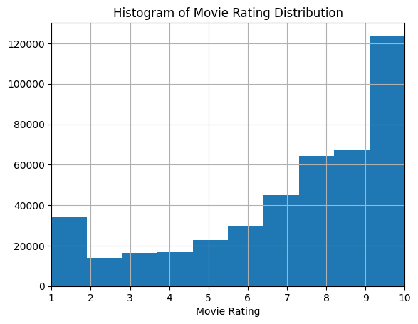

```python
hist = df['rating'].hist(bins=10)
plt.title('Histogram of Movie Rating Distribution')
plt.xlabel('Movie Rating')
plt.xlim(1, 10)
plt.show()
```

We now trim down the dataset so that we have an equal distribution of all ratings. And we also shuffle the data.

```python
#Shuffle the data
from sklearn.utils import shuffle
df = shuffle(df)

df.to_csv('sampled_df.csv', index=False)
```

```python
total_sample_size = 50000
unique_ratings = df['rating'].nunique()
samples_per_category = total_sample_size // unique_ratings  # Integer division to get samples per category

if total_sample_size % unique_ratings != 0:
    print(f"Warning: {total_sample_size} is not evenly divisible by {unique_ratings} categories. " +
          f"Actual total sample size will be {samples_per_category * unique_ratings}.")

# Uniformly sample rows from each rating category
sampled_df = df.groupby('rating').apply(lambda x: x.sample(n=samples_per_category)).reset_index(drop=True)

# Check the final sample size and distribution
print(f"Final sample size: {len(sampled_df)}")
print(sampled_df['rating'].value_counts())
sampled_df.to_csv('sampled_df.csv', index=False)
```

```
Final sample size: 50000
rating
1     5000
2     5000
3     5000
4     5000
5     5000
6     5000
7     5000
8     5000
9     5000
10    5000
Name: count, dtype: int64
```

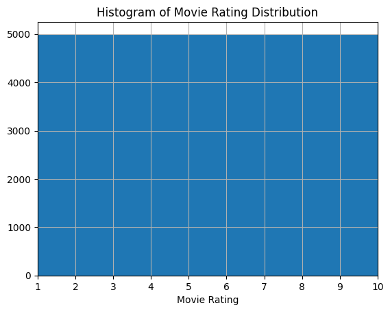

```python
hist = sampled_df['rating'].hist(bins=10)
plt.title('Histogram of Movie Rating Distribution')
plt.xlabel('Movie Rating')
plt.xlim(1, 10)
plt.show()
```

### Clean the data

```python
sampled_df = pd.read_csv('sampled_df.csv')

sampled_df['review'] = sampled_df['review'].fillna('')
sampled_df['review'] = sampled_df['review'].astype(str)

# Clean up text per https://medium.com/@AMustafa4983/sentiment-analysis-on-imdb-movie-reviews-a-beginners-guide-d5136ec74e56

import re
import string
import nltk
from nltk.corpus import stopwords
from nltk.stem.porter import *

nltk.download('stopwords')

def remove_stopwords(text):
    stop_words = stopwords.words('english')
    words = text.split()
    filtered_sentence = ''
    for word in words:
        if word not in stop_words:
            filtered_sentence = filtered_sentence + word + ' '
    return filtered_sentence

def normalize_text(text):
    text = text.lower()
    # get rid of urls
    text = re.sub('https?://\S+|www\.\S+', '', text)
    # get rid of non words and extra spaces
    text = re.sub('\\W', ' ', text)
    text = re.sub('\n', '', text)
    text = re.sub(' +', ' ', text)
    text = re.sub('^ ', '', text)
    text = re.sub(' $', '', text)
    return text

def remove_punctuation(text):
    table = str.maketrans('','',string.punctuation)
    words = text.split()
    filtered_sentence = ''
    for word in words:
        word = word.translate(table)
        filtered_sentence = filtered_sentence + word + ' '
    return filtered_sentence

def stemming(text):
    ps = PorterStemmer()
    words = text.split()
    filtered_sentence = ''
    for word in words:
        word = ps.stem(word)
        filtered_sentence = filtered_sentence + word + ' '
    return filtered_sentence

def clean_text(text):
    text = text.lower()
    text = text.replace(',',' , ')
    text = text.replace('.',' . ')
    text = text.replace('/',' / ')
    text = text.replace('@',' @ ')
    text = text.replace('#',' # ')
    text = text.replace('?',' ? ')
    text = normalize_text(text)
    text = remove_punctuation(text)
    #text = remove_stopwords(text)
    #text = stemming(text)
    return text

Xt = [clean_text(text) for text in sampled_df['review'].tolist()]

sampled_df.review = pd.DataFrame(Xt)
```

Back to Top

## 4.0 Training a Model from Scratch

#### Train a model from scratch to perform the classification task (this does NOT need to be a transformer). That is, do not use transfer learning for the classification task. Verify the model converges (even if the model is overfit). This does NOT need to mirror the foundational model. This model may be far less computational to train.

For our basic model, we generate the embeddings and perform an average pooling across the sequence, followed by a dense layer to generalize the embeddings, a dropout layer to help with overfitting, and last an activation layer to classify the sequence. In this way, the pooling and the dense layer capture the sequence as a whole in an attempt to gather the context of the overall sequence.

### Model

```python
sampled_df = pd.read_csv('sampled_df.csv')

sampled_df.rating.replace(to_replace = [1,2,3,4,5,6,7,8,9,10],
               value = [0,0,0,0,0,
                        1,1,1,1,1],
                inplace=True)
sampled_df
```

|  | rating | review |
| --- | --- | --- |
| 0 | 0 | i was so looking forward to this movie because... |
| 1 | 0 | i personally did not like the movie for severa... |
| 2 | 0 | well the movie is very flat even the animals f... |
| 3 | 0 | with a cast of four hollywood heavy weights th... |
| 4 | 0 | oh dear i can t remember the last time i watch... |
| ... | ... | ... |
| 49995 | 1 | the shawshank very nice and this movie a short... |
| 49996 | 1 | there are some seriously seriously boring peop... |
| 49997 | 1 | every time they show jerry maguire movie i wat... |
| 49998 | 1 | even days after watching this i literally cann... |
| 49999 | 1 | was a brilliant movie beginning was a bit slow... |

50000 rows × 2 columns

```python
from keras import metrics
from keras import backend as K

def recall_m(y_true, y_pred):
    true_positives = K.sum(K.round(K.clip(y_true * y_pred, 0, 1)))
    possible_positives = K.sum(K.round(K.clip(y_true, 0, 1)))
    recall = true_positives / (possible_positives + K.epsilon())
    return recall

def precision_m(y_true, y_pred):
    true_positives = K.sum(K.round(K.clip(y_true * y_pred, 0, 1)))
    predicted_positives = K.sum(K.round(K.clip(y_pred, 0, 1)))
    precision = true_positives / (predicted_positives + K.epsilon())
    return precision

def f1_m(y_true, y_pred):
    precision = precision_m(y_true, y_pred)
    recall = recall_m(y_true, y_pred)
    return 2*((precision*recall)/(precision+recall+K.epsilon()))
```

```python
def plothistory(history, label1, label2 ):
    # Plot training & validation accuracy values
    plt.plot(history.history['accuracy'])
    plt.plot(history.history['val_accuracy'])
    plt.title('Model accuracy')
    plt.ylabel('Accuracy')
    plt.xlabel('Epoch')
    plt.legend([label1, label2], loc='upper left')
    plt.show()

    # Plot training & validation loss values
    plt.plot(history.history['loss'])
    plt.plot(history.history['val_loss'])
    plt.title('Model loss')
    plt.ylabel('Loss')
    plt.xlabel('Epoch')
    plt.legend([label1, label2], loc='upper left')
    plt.show()
```

```python
from keras.models import Sequential
from keras.layers import Embedding, Conv1D, GlobalMaxPooling1D, Dense, Dropout, GlobalAveragePooling1D
from keras.preprocessing.text import Tokenizer
import tensorflow as tf
```

### train_test_split

```python
X = sampled_df['review'].astype(str)
y = sampled_df['rating']
X_train, X_test, y_train, y_test = train_test_split(X,
                                                   y,
                                                   test_size=0.2,
                                                   random_state=42,
                                                   shuffle=True)
```

### Tokenization

```python
# important properties
vocab_size = 10000
max_length = 100

trunc_type = 'post'
padding_type = 'post'
oov_tok = '<OOV>'

# Define tokenizer and fit on texts
tokenizer = Tokenizer(num_words=vocab_size, oov_token=oov_tok)
tokenizer.fit_on_texts(X_train)
vocab_size = len(tokenizer.word_index)+1  # Adding 1 to account for the reserved 0 index
# Let's Tokenize and pad texts
X_train = tokenizer.texts_to_sequences(X_train)
X_test = tokenizer.texts_to_sequences(X_test)

X_train = tf.keras.utils.pad_sequences(X_train, maxlen=max_length,
                         padding=padding_type,
                         truncating=trunc_type)
X_test = tf.keras.utils.pad_sequences(X_test, maxlen=max_length,
                         padding=padding_type,
                         truncating=trunc_type)
```

### Train Model

```python
from keras.layers import LSTM
from keras.optimizers import Adam
from keras.layers import Embedding, Conv1D, GlobalMaxPooling1D, Dense, Dropout, GlobalAveragePooling2D, GlobalMaxPooling2D
from keras.callbacks import EarlyStopping

model = Sequential()
model.add(Embedding(vocab_size, 64, input_length=max_length))
model.add(GlobalAveragePooling1D())
model.add(Dense(10, activation='relu'))
model.add(Dropout(0.5))
model.add(Dense(1, activation='sigmoid'))  # 2 rating classes
optimizer = Adam(lr=0.001)
model.compile(optimizer=optimizer,
              loss='binary_crossentropy',
              metrics=['accuracy',f1_m,precision_m, recall_m])
```

```python
model.summary()
```

```
Model: "sequential_15"
_________________________________________________________________
 Layer (type)                Output Shape              Param #
=================================================================
 embedding_12 (Embedding)    (None, 100, 64)           4836032

 global_average_pooling1d_2   (None, 64)               0
 (GlobalAveragePooling1D)

 dense_10 (Dense)            (None, 10)                650

 dropout_5 (Dropout)         (None, 10)                0

 dense_11 (Dense)            (None, 1)                 11

=================================================================
Total params: 4,836,693
Trainable params: 4,836,693
Non-trainable params: 0
_________________________________________________________________
```

```python
batch_size = 250
history = model.fit(X_train,y_train,epochs=100,batch_size=batch_size,validation_split=.2) #,callbacks=[early_stopping])
```

### Plot Convergence

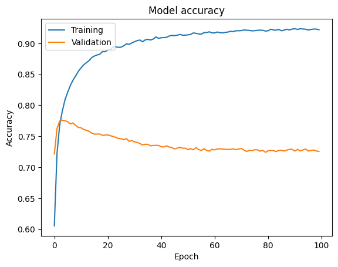

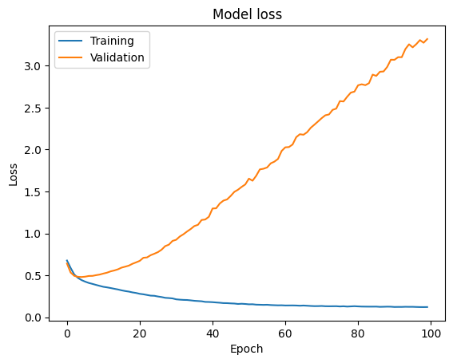

```python
plothistory(history, 'Training', 'Validation')
```

```python
y_pred = model.predict(X_test)
y_pred =np.round(y_pred,0).astype(int)
```

```python
score = model.evaluate(np.asarray(X_test),np.asarray(y_test))
```

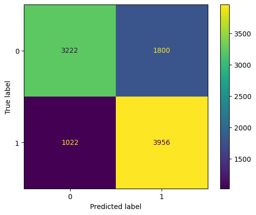

```python
from sklearn.metrics import ConfusionMatrixDisplay, confusion_matrix

conf_mat = confusion_matrix(y_test, y_pred)
cm_display = ConfusionMatrixDisplay(conf_mat).plot()
```

### Summary for Scratch Model:

For the scratch model, we see that the training accuracy and loss performance converges. However, the test dataset does not perform as well for this initial model, in that they both diverge. Regardless, we do achieve around 70% accuracy for both the Validation and Test Data. Further, our F1 score achieves nearly 70%, so that we show we are converging towards the right solution on appropriately classifying these reviews as Positive or Negative.

We will now evaluate this task using Transfer Learning with the DistilBERT Transformer to see if we have improvements in the performance.

Back to Top

## 5.0 Training a Model by Transfer Learning from Foundational Model

#### Train a model by transfer learning from your foundational model. Verify that the new model converges. You only need to train a model using the bottleneck features for this step.

We evaluated several approaches for this task, but one structure we found that was interesting was in the following link: https://medium.com/geekculture/hugging-face-distilbert-tensorflow-for-custom-text-classification-1ad4a49e26a7

We use tensorflow for the DistilBERT processing and created a funtion to loop through all our data and extract the pertinent information for the transformer. We then perform a similar neural network sequence as the Scratch Model on top of DistilBERT to generalize our features and classify them as Positive or Negative.

```python
import numpy as np
import pandas as pd
from keras.models import Sequential
from keras.layers import Dense, Input
from transformers import DistilBertTokenizer, TFDistilBertModel, TFDistilBertForSequenceClassification
from transformers import DistilBertTokenizerFast, AutoTokenizer
from sklearn.model_selection import train_test_split
import tensorflow as tf

max_length = 100
batch_size = 125

sampled_df = pd.read_csv('sampled_df_bin.csv')
sampled_df['review'] = sampled_df['review'].fillna('')
sampled_df['review'] = sampled_df['review'].astype(str)
sampled_df = sampled_df[['review','rating']]

X = sampled_df['review'].tolist()
y = sampled_df['rating'].tolist() # binary classes


#Train validation split
X_train, X_val, y_train, y_val = train_test_split(X, y, test_size=0.2, random_state=42)
#Train test split
X_train, X_test, y_train, y_test = train_test_split(X_train, y_train, test_size=0.2, random_state=42)

tokenizer = DistilBertTokenizer.from_pretrained('distilbert-base-uncased')
distil_bert = TFDistilBertModel.from_pretrained('distilbert-base-uncased')

#At first we freeze it, with distil_bert freeze all or none
for layer in distil_bert.layers:
    layer.trainable = True # we will freeze in fine tuning learning


def extract_features_in_batches(reviews, batch_size=32):
    all_features = []

    for i in range(0, len(reviews), batch_size):
        batch_reviews = reviews[i:i+batch_size]
        inputs = tokenizer(batch_reviews, padding=True, truncation=True, max_length=max_length, return_tensors="tf")
        outputs = distil_bert(inputs['input_ids'], attention_mask=inputs['attention_mask'])
        features = outputs.last_hidden_state[:, 0, :].numpy()  # Extract
        all_features.append(features)

    all_features = np.vstack(all_features)
    return all_features
```

```python
#https://towardsdatascience.com/hugging-face-transformers-fine-tuning-distilbert-for-binary-classification-tasks-490f1d192379
# Define the maximum number of words to tokenize (DistilBERT can tokenize up to 512)
MAX_LENGTH = 100

#needed later
# Define function to encode text data in batches
def batch_encode(tokenizer, texts, batch_size=256, max_length=MAX_LENGTH):
    """""""""
    A function that encodes a batch of texts and returns the texts'
    corresponding encodings and attention masks that are ready to be fed
    into a pre-trained transformer model.

    Input:
        - tokenizer:   Tokenizer object from the PreTrainedTokenizer Class
        - texts:       List of strings where each string represents a text
        - batch_size:  Integer controlling number of texts in a batch
        - max_length:  Integer controlling max number of words to tokenize in a given text
    Output:
        - input_ids:       sequence of texts encoded as a tf.Tensor object
        - attention_mask:  the texts' attention mask encoded as a tf.Tensor object
    """""""""

    input_ids = []
    attention_mask = []

    for i in range(0, len(texts), batch_size):
        batch = texts[i:i+batch_size]
        inputs = tokenizer.batch_encode_plus(batch,
                                             max_length=max_length,
                                             padding='longest', #implements dynamic padding
                                             truncation=True,
                                             return_attention_mask=True,
                                             return_token_type_ids=False
                                             )
        input_ids.extend(inputs['input_ids'])
        attention_mask.extend(inputs['attention_mask'])


    return tf.convert_to_tensor(input_ids), tf.convert_to_tensor(attention_mask)


# Encode X_train
X_train_ids, X_train_attention = batch_encode(tokenizer, X_train)

# Encode X_valid
X_valid_ids, X_valid_attention = batch_encode(tokenizer, X_val)

# Encode X_test
X_test_ids, X_test_attention = batch_encode(tokenizer, X_test)
```

```python
def prep_labels(labels, batch_size=32):
    all_labels = []

    for i in range(0, len(labels), batch_size):
        batches= labels[i:i+batch_size]
        all_labels.extend(batches)

    all_labels = np.vstack(all_labels)
    return all_labels
```

```python
X_train_features = np.load('sc_results_0307/bottleneck_train_features.npy')
y_train_labels = np.load('sc_results_0307/train_ratings.npy')

X_val_features = np.load('sc_results_0307/bottleneck_val_features.npy')
y_val_labels = np.load('sc_results_0307/val_ratings.npy')
```

```python
from keras.optimizers import Adam
from keras.layers import Dropout
top_model = Sequential()
top_model.add(Dense(100, activation='relu', input_shape=(X_train_features.shape[1],)))
top_model.add(Dropout(0.5))
top_model.add(Dense(1, activation='sigmoid'))  # 2 rating classes
optimizer = Adam(lr=0.001)
top_model.compile(optimizer=optimizer,
              loss='binary_crossentropy',
              metrics=['accuracy',f1_m,precision_m, recall_m])
```

```python
top_model.summary()
```

```
Model: "sequential_16"
_________________________________________________________________
 Layer (type)                Output Shape              Param #
=================================================================
 dense_12 (Dense)            (None, 100)               76900

 dropout_44 (Dropout)        (None, 100)               0

 dense_13 (Dense)            (None, 1)                 101

=================================================================
Total params: 77,001
Trainable params: 77,001
Non-trainable params: 0
_________________________________________________________________
```

```python
#Fit

import time

start_time = time.time()
history = top_model.fit(X_train_features, y_train_labels,
                    epochs=100,
                    batch_size=32
                    ,validation_data=(X_val_features, y_val_labels)
                    )

elapsed_time = time.time() - start_time

print(f"Training took {elapsed_time:.2f} seconds.")

# Save the training history to a CSV file
histdf = pd.DataFrame(history.history)
histdf.to_csv('sc_results_0307/distilbert_model_training_history.csv', index=False)
```

```
Training took 166.46 seconds.
```

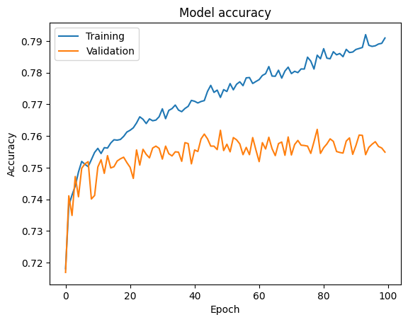

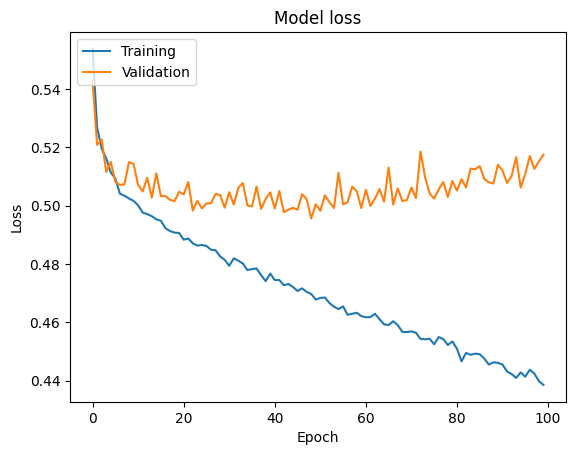

```python
plothistory(history, 'Training', 'Validation')
```

### Summary for Foundational Model:

For the foundational model, we again see convergence on training accuracy & loss, and we also see that the validation accuracy and loss appear to settle without diverging. The model achieved a 75% Validation accuracy, which was better than the Scratch model. Further, the F1 score was slightly improved at 74%.

We will now evaluate this task using by fine-tuning the DistilBERT Transformer to see if we have improvements in the performance.

Back to Top

## 6.0 Fine-Tuning the Model

#### Perform fine tuning upon the model by training some layers within the foundational model. Verify that the model converges.

```python
#Load the saved files to be added later
from tensorflow.keras.models import Model
# Input layers
input_ids = tf.keras.layers.Input(shape=(max_length,), dtype=tf.int32, name='input_ids')
attention_masks = tf.keras.layers.Input(shape=(max_length,), dtype=tf.int32, name='attention_mask')

# BERT layer
last_hidden_state = distil_bert(input_ids, attention_mask=attention_masks)[0]
cls_token = last_hidden_state[:, 0, :]

# Custom layers on top of BERT output...
x= Dense(100, activation='relu')(cls_token)
x = Dropout(0.5)(x)
fine_output=Dense(1, activation='sigmoid')(x)

fine_model = Model(inputs=[input_ids, attention_masks], outputs=fine_output)
```

```python
# Freeze all layers in the DistilBERT model
for layer in distil_bert.layers:
    layer.trainable = False

print(distil_bert.distilbert.transformer.layer[-1].trainable)
# Unfreeze the last transformer layer
distil_bert.distilbert.transformer.layer[-1].trainable = True

print(distil_bert.distilbert.transformer.layer[-1].trainable)
optimizer = Adam(lr=0.01)
fine_model.compile(loss='binary_crossentropy', optimizer =optimizer,
              #optimizer=tf.keras.optimizers.SGD(learning_rate=1e-4, momentum=0.9),
               metrics=['accuracy',f1_m,precision_m, recall_m])


fine_model.summary()
```

```
False
True
Model: "model"
__________________________________________________________________________________________________
 Layer (type)                   Output Shape         Param #     Connected to
==================================================================================================
 input_ids (InputLayer)         [(None, 100)]        0           []

 attention_mask (InputLayer)    [(None, 100)]        0           []

 tf_distil_bert_model_1 (TFDist  TFBaseModelOutput(l  66362880   ['input_ids[0][0]',
 ilBertModel)                   ast_hidden_state=(N               'attention_mask[0][0]']
                                one, 100, 768),
                                 hidden_states=None
                                , attentions=None)

 tf.__operators__.getitem (Slic  (None, 768)         0           ['tf_distil_bert_model_1[0][0]']
 ingOpLambda)

 dense_14 (Dense)               (None, 100)          76900       ['tf.__operators__.getitem[0][0]'
                                                                 ]

 dropout_45 (Dropout)           (None, 100)          0           ['dense_14[0][0]']

 dense_15 (Dense)               (None, 1)            101         ['dropout_45[0][0]']

==================================================================================================
Total params: 66,439,881
Trainable params: 77,001
Non-trainable params: 66,362,880
__________________________________________________________________________________________________
```

```python
checkpoint_filepath = 'models/checkpoint'
model_checkpoint_callback = tf.keras.callbacks.ModelCheckpoint(
    filepath=checkpoint_filepath,
    save_weights_only=True,
    monitor='val_accuracy',
    mode='max',
    save_best_only=True)

print('Fine tuning combined model...')
history = fine_model.fit(
                x=[X_train_ids, X_train_attention],
                y= y_train_labels,
                epochs=5,
                batch_size=32,
                callbacks=[model_checkpoint_callback],
                validation_data = ([X_valid_ids, X_valid_attention], y_val_labels),
                verbose=1)
```

```
Fine tuning combined model...
```

We will now further compare the models in terms of several aspects, such as overall classification performance and efficiency.

Back to Top

## 7.0 Results: Comparing All Investigated Models

#### Report the results of all models using the evaluation procedure that you argued for at the beginning of the lab. Compare the convergence of the models and the running time. Results should be reported with proper statistical comparisons and proper visualizations.

### Compare F1 Scores

We will use the F1 scores of the scratch and transfer learning models to compare the effect of adding in DistilBERT.

```python
import pandas as pd
top_history = pd.read_csv("sc_results_0307/sc_results_0307_base_model_training_history2bin.csv")
transfer_history = pd.read_csv("sc_results_0307/distilbert_model_training_history.csv")

time1 = 12*60 + 2.7    # Scratch
time2 = 157.52  # DistilBERT
```

```python
df1 = pd.DataFrame(top_history)
df2 = pd.DataFrame(transfer_history)
```

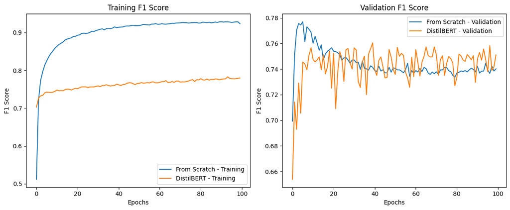

```python
# Ensure both DataFrames have the same number of epochs
min_epochs = min(len(df1.index), len(df2.index))
df1 = df1.head(min_epochs)
df2 = df2.head(min_epochs)

# Visualization
plt.figure(figsize=(12, 5))

# Training F1
plt.subplot(1, 2, 1)
plt.plot(df1['f1_m'], label='From Scratch - Training')
plt.plot(df2['f1_m'], label='DistilBERT - Training')
plt.title('Training F1 Score')
plt.xlabel('Epochs')
plt.ylabel('F1 Score')
plt.legend()

# Validation F1
plt.subplot(1, 2, 2)
plt.plot(df1['val_f1_m'], label='From Scratch - Validation')
plt.plot(df2['val_f1_m'], label='DistilBERT - Validation')
plt.title('Validation F1 Score')
plt.xlabel('Epochs')
plt.ylabel('F1 Score')
plt.legend()

plt.tight_layout()
plt.show()
```

The scratch model appears to overfit to the training data and quickly drops points, while the DistilBERT model appears to vary between epochs but gradually increases over time. To be certain that there is any difference in the models, let's take a T-test.

```python
# Statistical Analysis
# Compare F1 scores using t-test
from scipy.stats import ttest_ind
t_stat, p_val = ttest_ind(df1['val_f1_m'], df2['val_f1_m'])
print(f"T-statistic: {t_stat}, P-value: {p_val}")
```

```
T-statistic: 0.9257076261265449, P-value: 0.35572484215347566
```

### Compare Running Times

Since the difference in the models' performance when adding DistilBERT was negligible, let's consider the running times.

```
100
7.227
1.5752000000000002
```

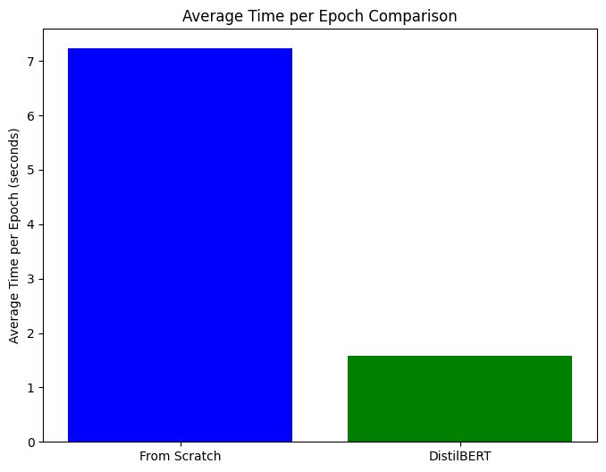

```python
# Calculate average time per epoch for each model
avg_time_per_epoch_model1 = time1 / min_epochs
avg_time_per_epoch_model2 = time2 / min_epochs

# Values and labels for the plot
values = [avg_time_per_epoch_model1, avg_time_per_epoch_model2]
labels = ['From Scratch', 'DistilBERT']

# Create a bar chart
plt.figure(figsize=(8, 6))
plt.bar(labels, values, color=['blue', 'green'])

# Add titles and labels
plt.title('Average Time per Epoch Comparison')
plt.ylabel('Average Time per Epoch (seconds)')

print(min_epochs)
print(avg_time_per_epoch_model1)
print(avg_time_per_epoch_model2)

# Show the plot
plt.show()
```

The scratch model took about 7 seconds per epoch while the transfer learning model only took about 2 seconds per epoch.

One explanation for this discrepancy could be that the DistilBERT layers contain pre-trained weights fit for the task and that they are optimized for performance.

Another explanation could be that, in order to go from our Embedding layer to a 1-dimensional output in the scratch model, we used a Pooling layer which added some computation and runtime to the scratch model, whereas in the DistilBERT model we were able to simply load the bottleneck features and plug them into the Dense layers right away.

Let's look at the total running time after 100 epochs compared to how well the models performed

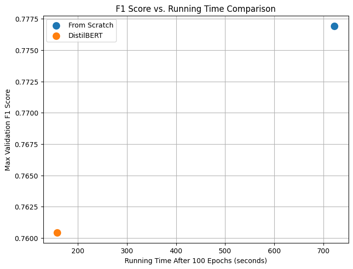

```python
# Extract the final (or max) F1 scores from the validation sets of both models
f1_model1 = df1['val_f1_m'].max()
f1_model2 = df2['val_f1_m'].max()

# Your running times are stored in time1 and time2 variables
running_time_model1 = avg_time_per_epoch_model1 * min_epochs
running_time_model2 = avg_time_per_epoch_model2 * min_epochs

f1_scores = [f1_model1, f1_model2]  # F1 scores for both models
running_times = [running_time_model1, running_time_model2]  # Running times for both models
labels = ['From Scratch', 'DistilBERT']

# Create a scatter plot
plt.figure(figsize=(8, 6))
for i in range(len(f1_scores)):
    plt.scatter(running_times[i], f1_scores[i], label=labels[i], s=100)  # s is the size of the point

# Add titles and labels
plt.title('F1 Score vs. Running Time Comparison')
plt.xlabel(f'Running Time After {min_epochs} Epochs (seconds)')
plt.ylabel('Max Validation F1 Score')
plt.legend()

# Show the plot
plt.grid(True)
plt.show()
```

After 100 epochs, the DistilBERT model performed very slightly lower (max F1 score), or mostly the same, but took significantly less time to train.

### Compare Fine-Tuned Model

Let's compare the F1 scores between the fine-tuned model and the original DistilBERT model.

Note that we only trained the fine-tuned model for 5 epochs.

```python
fine_history = pd.read_csv("sc_results_0307/distilbert_fine_model_training_history_bin.csv")
```

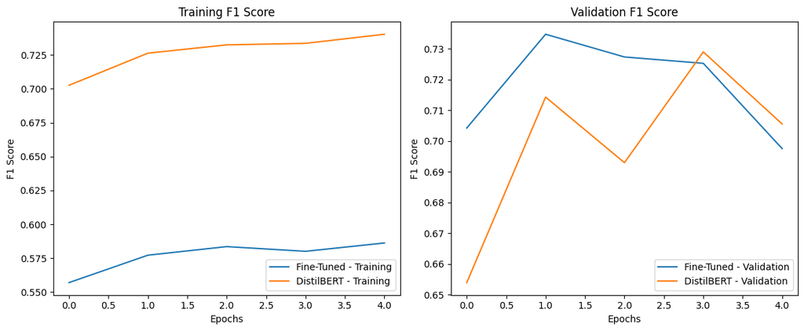

```python
# Convert histories to DataFrames if they're not already
df1 = pd.DataFrame(fine_history)
df2 = pd.DataFrame(transfer_history)

# Ensure both DataFrames have the same number of epochs
min_epochs = min(len(df1), len(df2))
df1 = df1.head(min_epochs)
df2 = df2.head(min_epochs)

# Visualization
plt.figure(figsize=(12, 5))

# Training F1
plt.subplot(1, 2, 1)
plt.plot(df1['f1_m'], label='Fine-Tuned - Training')
plt.plot(df2['f1_m'], label='DistilBERT - Training')
plt.title('Training F1 Score')
plt.xlabel('Epochs')
plt.ylabel('F1 Score')
plt.legend()

# Validation F1
plt.subplot(1, 2, 2)
plt.plot(df1['val_f1_m'], label='Fine-Tuned - Validation')
plt.plot(df2['val_f1_m'], label='DistilBERT - Validation')
plt.title('Validation F1 Score')
plt.xlabel('Epochs')
plt.ylabel('F1 Score')
plt.legend()

plt.tight_layout()
plt.show()
```

```python
# Statistical Analysis
# Compare F1 scores using t-test
t_stat, p_val = ttest_ind(df1['val_f1_m'], df2['val_f1_m'])
print(f"T-statistic: {t_stat}, P-value: {p_val}")
```

```
T-statistic: 1.2783325183291965, P-value: 0.2369705364449183
```

The P-value, greater than 0.05, suggests that we cannot reject the null hypothesis and that the observed difference in F1 scores is, again, not statistically significant.

For about the same performance, let's consider the running times again.

```python
time1 = 2*60*60 + 16*60 + 6 # Fine-Tuned
```

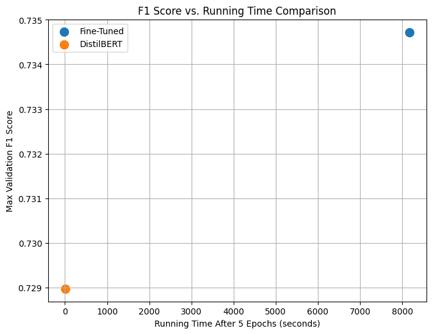

```python
# Extract the final (or max) F1 scores from the validation sets of both models
f1_model1 = df1['val_f1_m'].max()
f1_model2 = df2['val_f1_m'].max()

# Calculate average time per epoch for each model
avg_time_per_epoch_model1 = time1 / 5
avg_time_per_epoch_model2 = time2 / 100

running_time_model1 = avg_time_per_epoch_model1 * min_epochs
running_time_model2 = avg_time_per_epoch_model2 * min_epochs

f1_scores = [f1_model1, f1_model2]  # F1 scores for both models
running_times = [running_time_model1, running_time_model2]  # Running times for both models
labels = ['Fine-Tuned', 'DistilBERT']

# Create a scatter plot
plt.figure(figsize=(8, 6))
for i in range(len(f1_scores)):
    plt.scatter(running_times[i], f1_scores[i], label=labels[i], s=100)  # s is the size of the point

# Add titles and labels
plt.title('F1 Score vs. Running Time Comparison')
plt.xlabel(f'Running Time After {min_epochs} Epochs (seconds)')
plt.ylabel('Max Validation F1 Score')
plt.legend()

# Show the plot
plt.grid(True)
plt.show()
```

### Conclusion

```python
time1 = 3*60 + 12    # Scratch
time2 = 157.52  # DistilBERT
time3 = 2*60*60 + 16*60 + 6 # Fine-Tuned

df1 = pd.DataFrame(top_history)
df2 = pd.DataFrame(transfer_history)
df3 = pd.DataFrame(fine_history)
```

```python
import pandas as pd

# Assuming the rest of your setup from the previous code remains the same

# Define the calculate_metrics function
def calculate_metrics(df, total_time):
    max_f1_score = df['val_f1_m'].max()  # Assuming 'val_f1_m' is your validation F1 score column
    num_epochs = len(df)
    time_per_epoch = total_time / num_epochs
    return max_f1_score, num_epochs, time_per_epoch, max_f1_score / time_per_epoch  # Added efficiency metric

# Apply the function to each DataFrame
metrics1 = calculate_metrics(df1, time1)
metrics2 = calculate_metrics(df2, time2)
metrics3 = calculate_metrics(df3, time3)

# Compile the metrics into a new DataFrame for the summary
summary_df = pd.DataFrame(
    [metrics1, metrics2, metrics3],
    columns=['Max F1 Score', 'Number of Epochs', 'Time per Epoch (s)', 'F1 Efficiency (F1/Time per Epoch)'],
    index=['Model 1', 'Model 2', 'Model 3']
)

# Display the summary table
summary_df
```

[output not shown]

If we take the best F1 scores from each epoch, we can see that when adding DistilBERT with all of its layers frozen, we get the highest score in F1 efficiency. This, along with the low time per epoch, shows we got the best performance out of this model.